# Confidence intervals with Bootstrap

## Introduction to Bootstrapping

When we compute a confidence interval using the $t$-distribution, we rely on a mathematical model that assumes we know how the sample mean behaves under repeated sampling. In real applications, the true sampling distribution is almost never known and analytic formulas may be unreliable when the population is non-normal or when we care about statistics beyond the mean.

The **bootstrap** is a flexible, data-driven alternative.

### What is bootstrapping?

The bootstrap is a **resampling method** that treats the observed sample as a stand-in for the population.

1. Start with your original sample of size $n$.
2. Draw a **bootstrap sample** of size $n$ *with replacement* from the observed data.
3. Compute the statistic of interest (e.g., the sample mean) on that bootstrap sample.
4. Repeat steps 2–3 many times (e.g., 1,000–10,000) to form the **bootstrap distribution** of the statistic.

We use the bootstrap distribution to estimate uncertainty (a **bootstrap standard error**) and to form **confidence intervals** (e.g., **percentile** interval from quantiles, or **SE-based** interval using a critical value).

### Why is it called the “bootstrap”?

The term comes from **Bradley Efron (1979)**, inspired by “pulling oneself up by one’s bootstraps.” We approximate repeated sampling from the population by resampling the data we already have.

### Why it works (intuition)

If the original sample is representative, then resampling with replacement from that sample mimics new samples from the population. As a result, the variability across bootstrap statistics approximates the sampling variability of the estimator.

### When to use it (and when not to)

Bootstrapping is especially helpful when analytic standard errors are complicated or unreliable, or when we prefer a nonparametric approach. It works best with moderate-to-large $n$ (often $n>30$). It is **not** a remedy for very small samples; the method cannot create information that isn’t present in the data.

When (and why) to prefer the bootstrap

- **Non-normal or skewed data:** Classical $t$-intervals may perform poorly (esp. small–moderate $n$). The bootstrap builds an empirical sampling distribution without normality assumptions.
- **Complex estimators:** For medians, regression coefficients, ratios, etc., analytic SE formulas can be hard or unavailable; the bootstrap gives a general variability estimate.
- **Small-to-moderate samples (but not tiny):** When $n$ is not large enough for CLT guarantees but still informative, bootstrap CIs can be more accurate.
- **Nonparametric settings:** Avoid strong distributional assumptions; resample directly from the observed data instead of specifying a parametric family.
- **Model misspecification / heteroskedasticity:** In regression/ML, when residual assumptions fail (e.g., unequal variances), bootstrap can approximate correct variability.

When not to rely on it:

- **Very small samples:** If $n<20$, resampling cannot recover information that isn’t there.
- **Biased or unrepresentative samples:** Bootstrap can’t fix bad sampling; it only replicates what’s in the data.
- **Dependent / time-series data:** IID resampling breaks dependence structure (use block/bootstrap variants instead).

### Bootstrap CIs

Bootstrap confidence intervals have the same interpretation as classical ones e.g., a 95% bootstrap CI means that if we repeated the sampling and bootstrapping process many times, about 95% of the intervals would capture the true parameter. But unlike analytical methods, the bootstrap obtains this interval empirically rather than through formulas or assumptions.

## The data

In the previous lab, we looked at the population data of houses from Ames, Iowa. Let’s start by loading that data set.

```r
load("ames.RData")
```

In this lab we’ll start with a simple random sample of size 60 from the population. Specifically, this is a simple random sample of size 60. Note that the data set has information on many housing variables, but for the first portion of the lab we’ll focus on the size of the house, represented by the variable `Gr.Liv.Area`.

```r
set.seed(209)
population <- ames$Gr.Liv.Area
mu <- mean(population)
mu
```

```
## [1] 1499.69
```

```r
samp <- sample(population, 60)
```

The distribution of the sample looks right skewed.The median might be a better measure of centrality than the mean.

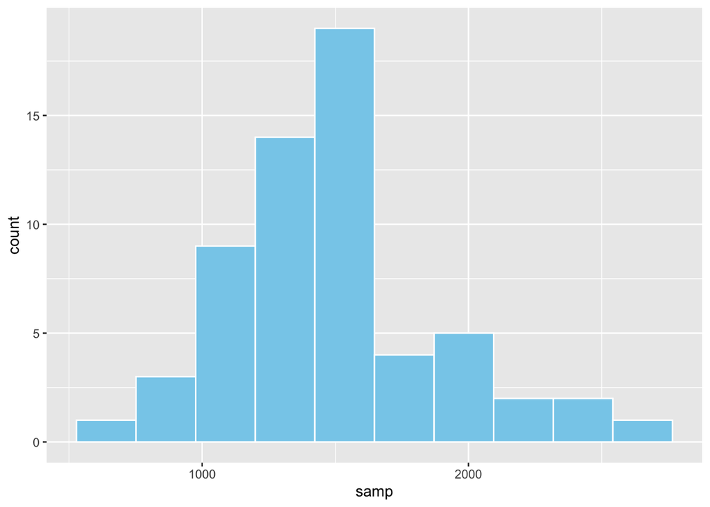

```r
library(ggplot2)
ggplot(data.frame(samp), aes(x = samp)) +
  geom_histogram(bins = 10, fill = "skyblue",
                 color = "white")
```

## Confidence intervals via the Bootstrap

For the purpose of illustration and comparison, we will calculate a CI for the mean.

```r
sample_mean <- mean(samp)
```

Here we will construct a confidence interval using the **bootstrap**, which creates a data-driven approximation to the sampling distribution by repeatedly resampling (with replacement) from the observed sample and recomputing the statistic (here, the mean) on each resample.

### A first bootstrap in R

```r
set.seed(123)
# One bootstrap resample and its mean
boot_sample <- sample(samp, replace = TRUE)
mean(boot_sample)
```

```
## [1] 1381.217
```

To approximate the bootstrap distribution of the sample mean, repeat the resampling many times:

```r
set.seed(123)
B <- 5000
boot_means <- replicate(B, mean(sample(samp, replace = TRUE)))
```

Visualize the **bootstrap distribution of the mean** and compare it to the original sample mean:

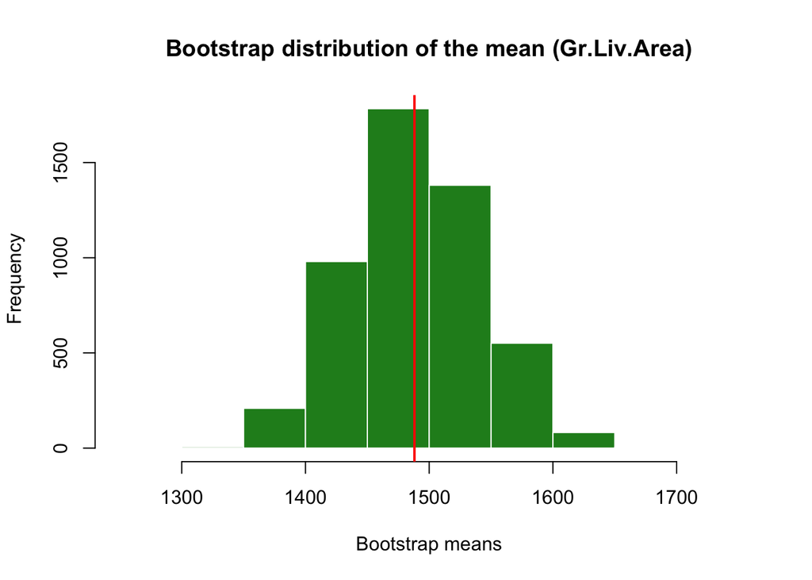

```r
hist(boot_means, main = "Bootstrap distribution of the mean (Gr.Liv.Area)",
     xlab = "Bootstrap means", col = "forestgreen", border = "white")
abline(v = sample_mean, col = "red", lwd = 2)
```

The bootstrap distribution for the mean usually looks normal, but not always. When it doesn’t, it’s telling you that the sample isn’t yet large enough or that the population is quite skewed.

| Situation | Shape of bootstrap distribution (mean) | Best interval |
| --- | --- | --- |
| Large (n), roughly symmetric data | Nearly normal | Either (SE-based or percentile) |
| Moderate (n), mild skew | Slightly skewed normal-like | Percentile bootstrap preferred |
| Small (n), highly skewed or heavy tails | Clearly non-normal | Percentile or bias-corrected bootstrap (not SE-based) |

### Percentile bootstrap confidence interval

Use the empirical quantiles of the bootstrap distribution:

```r
alpha <- 0.05
perc_ci <- quantile(boot_means, c(alpha/2, 1 - alpha/2))
perc_ci
```

```
##     2.5%    97.5%
## 1386.577 1592.851
```

### SE-based bootstrap confidence interval

Estimate the **bootstrap standard error** as the SD of the bootstrap means, then use $z^\star=1.96$ for a 95% CI:

```r
boot_se <- sd(boot_means)
zstar <- 1.96
se_ci <- c(sample_mean - zstar * boot_se, sample_mean + zstar * boot_se)
se_ci
```

```
## [1] 1384.405 1591.795
```

**Exercise 1:** Compare the percentile CI and the SE-based CI. Are they similar? Why might small differences occur?

| Method | How It’s Constructed | Key Assumptions |
| --- | --- | --- |
| **Percentile CI** | Uses the empirical percentiles of the bootstrap distribution (e.g., 2.5th and 97.5th percentiles for 95%). | Nonparametric — makes no assumptions about symmetry or normality. |
| **SE-based CI** | Uses the bootstrap standard error (the SD of bootstrap means) and multiplies it by a critical value (e.g., ( z^= 1.96 )). | Assumes the bootstrap distribution of the statistic is roughly normal and symmetric. |

Small differences arise when:

- The bootstrap distribution is slightly skewed (e.g., data are right-skewed).
- The sample size is small, so the estimated distribution of the statistic is noisy.
- The percentile method directly reflects the shape of the bootstrap distribution, while the SE method imposes a symmetric form centered on the mean.

In essence:

- The percentile CI adapts to skewness in the bootstrap distribution.
- The SE-based CI assumes symmetry and can under- or over-cover slightly in skewed cases.

## Comparing to a classical $t$-interval

Compute the traditional 95% confidence interval using the $t$-distribution. For large $n$, the $t$ and $z$ approaches are nearly identical.

```r
n <- length(samp)
s <- sd(samp)
se_t <- s / sqrt(n)
tstar <- qt(0.975, df = n - 1)
t_ci <- c(sample_mean - tstar * se_t, sample_mean + tstar * se_t)
t_ci
```

```
## [1] 1382.102 1594.098
```

**Exercise 2:** How does this analytical $t$-interval compare to the bootstrap intervals? When might a bootstrap approach be preferable?

## Confidence levels

**Exercise 3:** What does “95% confidence” mean in the context of bootstrap intervals?

A 95% bootstrap confidence interval for the mean means that the resampling procedure we used would capture the true mean roughly 95% of the time if we could repeat it over many random samples.

That is, we are 95% confident that the true population mean lies within this interval. This means that if we were to repeatedly take new samples and compute a bootstrap interval each time,about 95% of those intervals would contain the true mean.

Let’s check empirically the confidence level for the bootstrap confidence intervals.

```r
B <- 2000
n <- 60
lower_vector <- rep(NA, 50)
upper_vector <- rep(NA, 50)
```

Now we’re ready for the loop where we construct 50 bootstrap percentile CIs, each from a fresh random sample of size `n`.

```r
set.seed(42)
for(i in 1:50){
  # 1) obtain a fresh sample of size n from the population
  samp_i <- sample(population, n)
  # 2) build a bootstrap distribution of means
  boot_means_i <- replicate(B, mean(sample(samp_i, replace = TRUE)))
  # 3) store the percentile CI
  ci_i <- quantile(boot_means_i, c(0.025, 0.975))
  lower_vector[i] <- ci_i[1]
  upper_vector[i] <- ci_i[2]
}
```

Lower bounds of these 50 confidence intervals are stored in `lower_vector`, and the upper bounds are in `upper_vector`. Let’s view the first interval.

```r
c(lower_vector[1], upper_vector[1])
```

```
## [1] 1288.362 1554.302
```

Using the `plot_ci` function, plot all intervals. What proportion of your confidence intervals include the true population mean? Is this proportion exactly equal to the confidence level? If not, explain why.

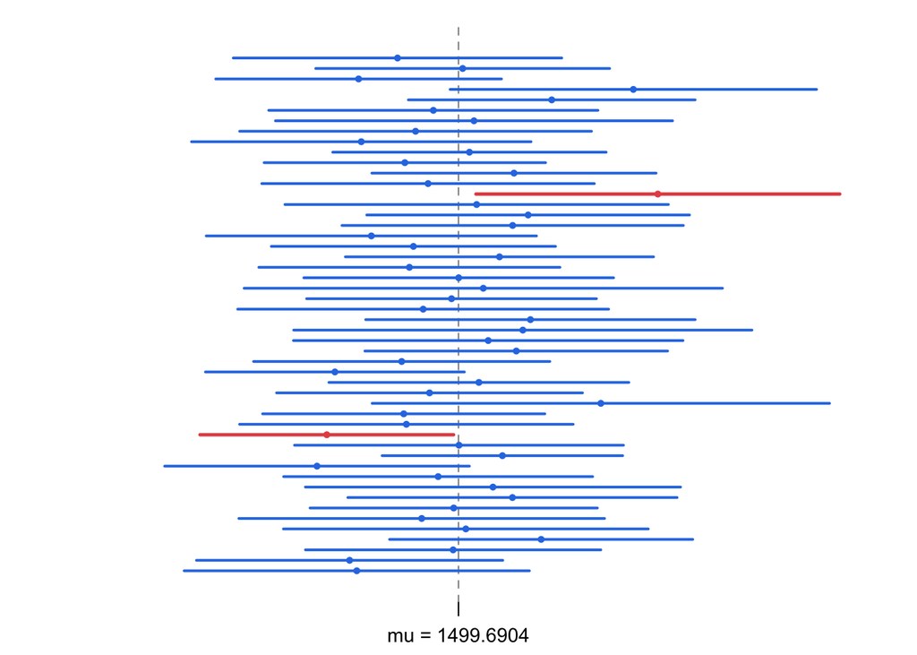

```r
source("plot_ci_v2.R")
plot_ci(lower_vector, upper_vector, mean(population))
```